# Group_Work_II

Sebastian Wijnroks, Lenny Hurni, Elia Aeby, Marc Steiner, Fidan Bekaj

2024-04-25

## Data Preperation

After loading the dataset with the tweets, we need to prepare the data accordingly. We remove duplicate tweets, the links within tweets, retweets are removed as well as emojis within the column User Description and Tweet. The emojis are removed with a function because we realized that packages for emoji removal are very dependent on the installed R-Version. To ensure it works for all users of this RMD File, we opted to go with a function.

Lastly, we create a new dataset “filtered_tweets” while also addressing bot-tweets. We do this by dropping all tweets from accounts who were created less than 10 days before the date of the tweet and have less than 5 followers. It won’t be possible to eliminate all bot tweets, however it can be reduced by a great amount. Furthermore we delete the column URL, as it has no real use for our analysis. Lastly we distinct the languages of the tweets, however only 343 of the total over 170’000 Tweets are non-english. We opted to drop them, so the filtered tweets are as well prepared as possible for the analysis.

## User Description

First off we create user_stats. It groups tweets by user and summarizes data such as the number of tweets, followers, account age, location, user description, and verification status. This helps identify the most active users and their characteristics.After this we focus on the location from where the user is from. We do this by filtering and counting the number of tweets by user location and creating a bar plot for the top 10 locations. This shows where the most active users are tweeting from. The results show, that most of the users tweeting about ChatGPT are from India and the United States. Furthermore we analyze the difference between tweets from verified and unverified users, clearly showing that most tweets are from unverified accounts. Lastly to find out more about the interests and topics of the user, we create a wordcloud from the column User Description. In this column, the user writes facts about himself. The analysis shows, that most users are from a tech background, alongside business and entreprenuers

```
## # A tibble: 6 × 7
##   User           TweetCount Followers DaysSinceCreation Location UserDescription
##   <chr>               <int>     <int>             <dbl> <chr>    <chr>
## 1 richardkimphd         897      4665              4651 ""       "Article, pape…
## 2 ChatGPTSpecial        349        72                34 ""       "Your source f…
## 3 BBacktesting          340       383               757 ""       "Algo trader, …
## 4 DataChaz              330     58120              5113 "London… "∙ Developer  …
## 5 saadnajeebsaad        255        83              3107 ""       ""
## 6 richgel999            232     13585              4326 "Approa… "Co-founder of…
## # ℹ 1 more variable: UserVerified <lgl>
```

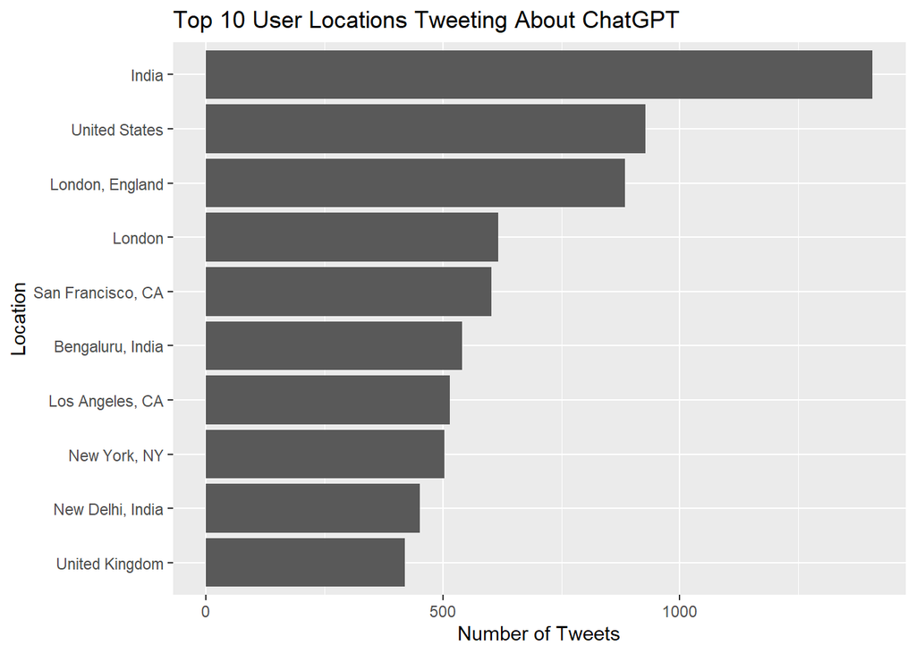

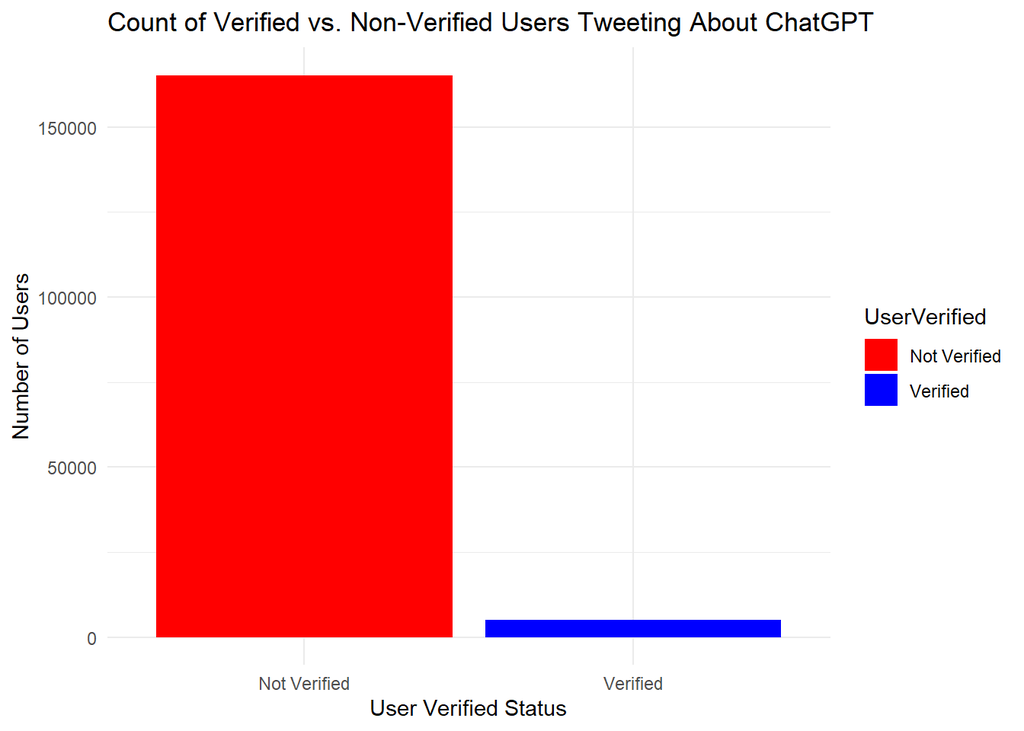

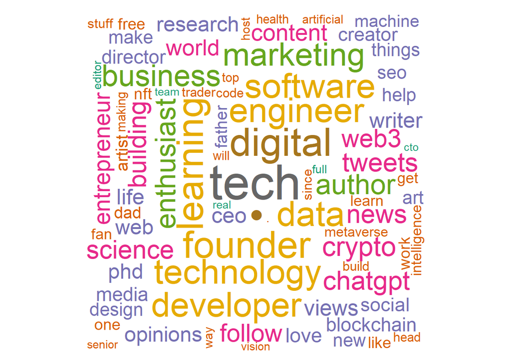

## Sentiment Analysis

To get an idea about the evolution of sentiment for or against ChatGPT we use ggplot2 and additionally the created at variable to plot it into a time frame of two months. We use three different categories, tweets with a sentiment score above 0 are labeled as positive, at 0 as neutral and below 0 as negative. The plot shows similarly to the histogram, that neutral and positive tweets are more or less the same over the timeframe, but overall always more than negative tweets. Therefore we can identify, that the majority of people tweeting about ChatGPT have a neutral / positive attitude against the AI. Next to this, the plot also shows the overall relevance of the topic ChatGPT over time showing that the begin of December 2022 being the most relevant time and begin of January the least relevant.

```
## # A tibble: 20 × 2
##    sentiments count
##         <int> <int>
##  1          0 71167
##  2          1 43544
##  3         -1 21506
##  4          2 17594
##  5          3  6492
##  6         -2  5118
##  7          4  2151
##  8         -3  1282
##  9          5   680
## 10         -4   378
## 11          6   179
## 12         -5   105
## 13          7    47
## 14          8    23
## 15         -6    21
## 16         -7     5
## 17          9     5
## 18         -8     2
## 19         -9     1
## 20         11     1
```

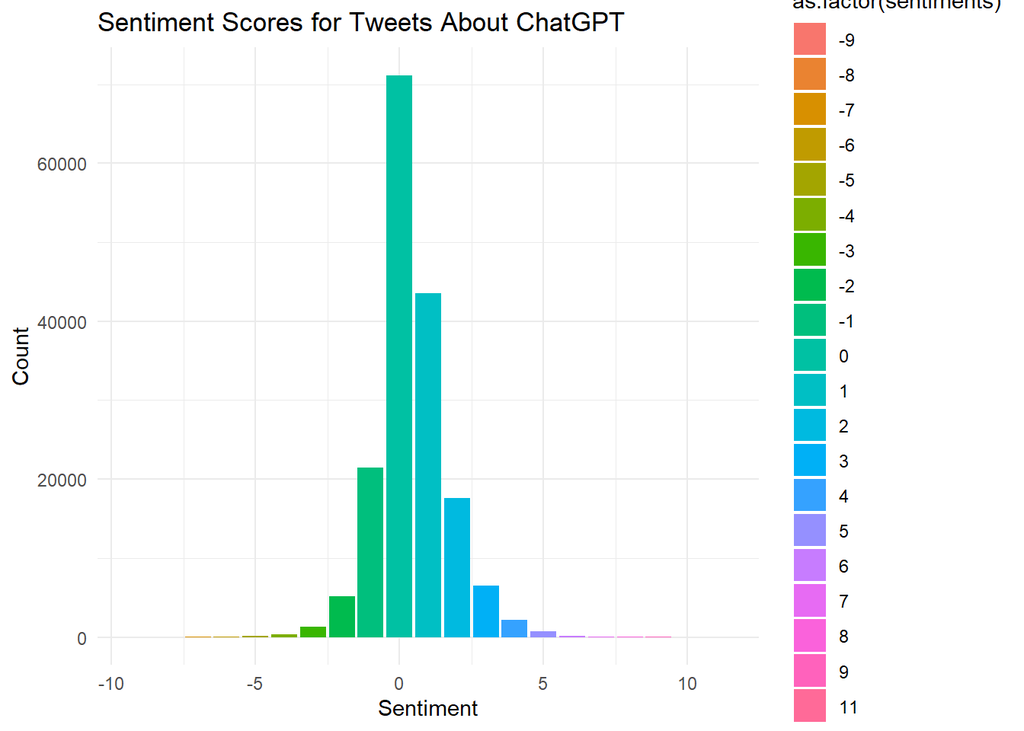

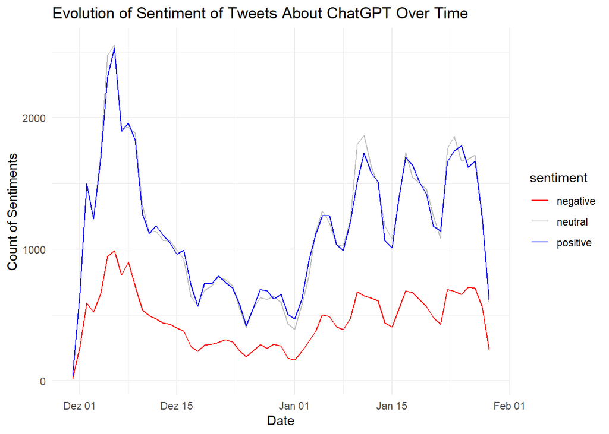

## Top Words

Next, we want to take a look with what topics ChatGPT is associated with by the users tweeting about it. First off we just take a basic look at what words are most often used. Naturally ChatGPT is the most used word, folllowed by AI, and OpenAI, the developer of ChatGPT.

```
##      word      n
## 1 chatgpt 189897
## 2      ai  54346
## 3  openai  24817
## 4   write   9743
## 5  google   8766
## 6     amp   7684
```

## Association / Topic Analysis

Next we take a more indepth look at the topics and associations. This code allows us to tag tweets with specific industries and applications, and then count how many tweets refer to these industries.

We first define custom dictionaries for industries (education, healthcare, finance, entertainment, technology, marketing) and applications (customer service, content creation, data analysis, software development, language translation). Each tweet is tagged with the most relevant industry and application based on the presence of these keywords. If no keywords are found, we assign “Other”. For the analysis we however drop the category other, because as most of the tweets do not refer to a industry it would distort the data. Same for the application, we only take a look at the tweets that actually refer to one of the defined applications and plot them using ggplot2.

```
##     industry    n
## 1 technology 4808
## 2  education 2980
## 3  marketing 2038
## 4 healthcare  386
## 5    finance  315
```

```
##            application   n
## 1     content creation 332
## 2     customer service 281
## 3 software development 102
## 4 language translation  67
## 5        data analysis  53
```

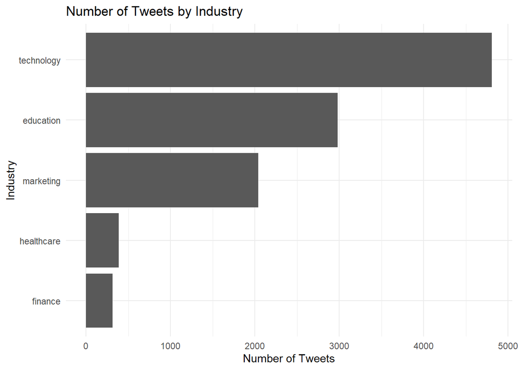

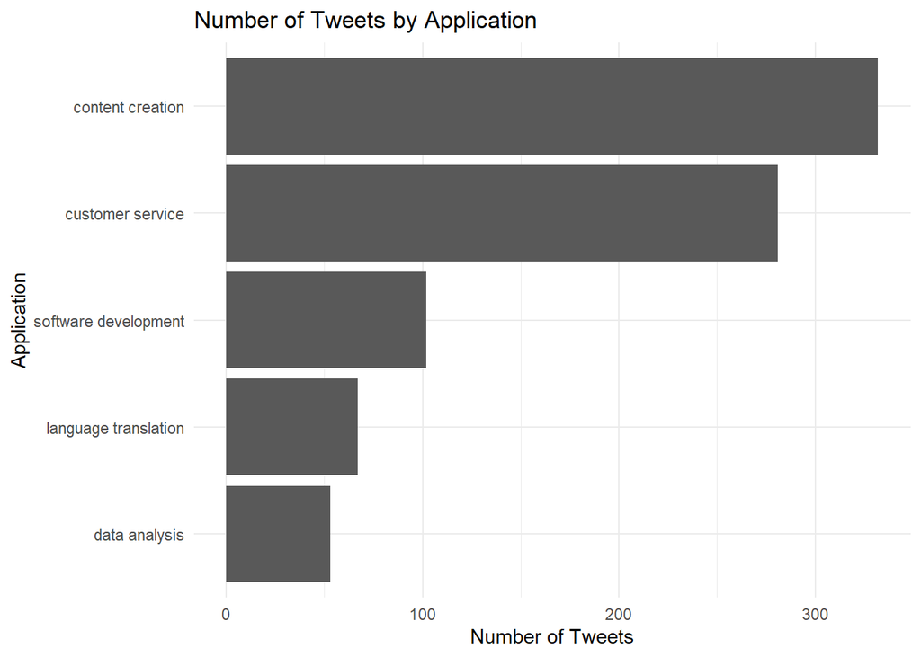

In the topic modeling section, we take a random sample of 10,000 tweets to manage memory usage. We preprocess the text by converting it to lowercase, removing punctuation, numbers, stop words, and extra whitespace. We create a Document-Term Matrix (DTM) with term frequency weighting and remove any empty rows.

```
## # A tibble: 50 × 3
##    topic term         beta
##    <int> <chr>       <dbl>
##  1     1 chatgpt   0.0604
##  2     1 google    0.0111
##  3     1 gpt       0.00598
##  4     1 many      0.00441
##  5     1 time      0.00430
##  6     1 answer    0.00429
##  7     1 people    0.00405
##  8     1 language  0.00399
##  9     1 amp       0.00398
## 10     1 microsoft 0.00389
## # ℹ 40 more rows
```

```
## # A tibble: 5 × 2
##   topic_label top_terms
##   <fct>       <chr>
## 1 1           chatgpt, google, gpt, many, time, answer, people, language, amp, …
## 2 2           chatgpt, openai, gpt, google, using, code, make, chat, know, ’s
## 3 3           chatgpt, openai, one, amp, new, technology, tech, ’s, gpt, need
## 4 4           chatgpt, write, openai, think, using, new, future, well, used, ai…
## 5 5           chatgpt, openai, think, tool, good, make, chat, amp, used, micros…
```

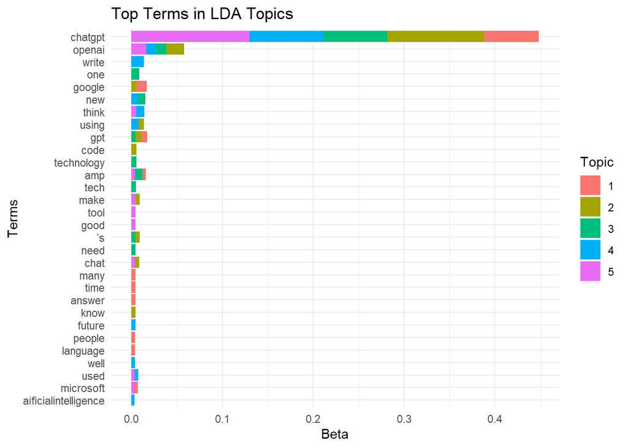

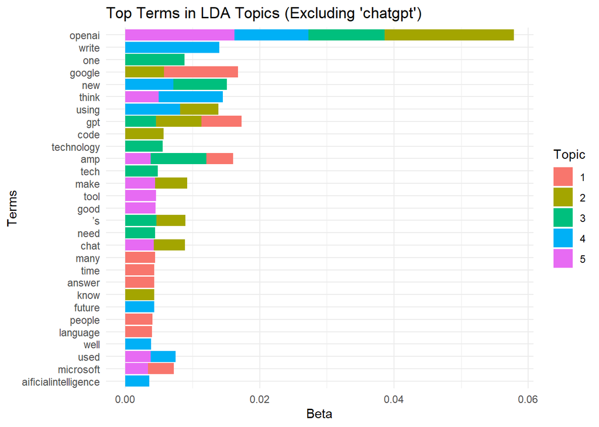

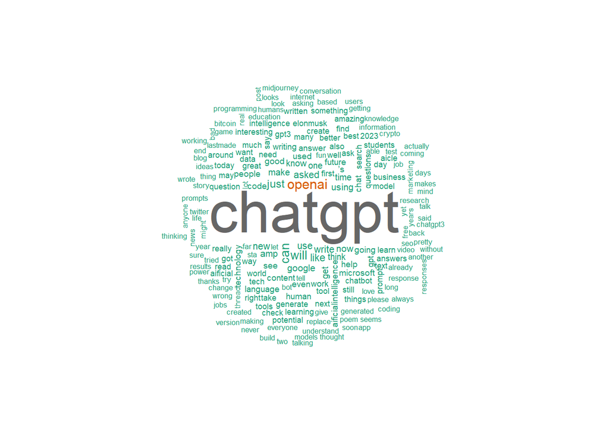

## Conclusion and advice to consulting company

You should consider integrating ChatGPT for tasks such as automating customer service, where it can handle common inquiries and free up human agents for more complex issues. In content creation, ChatGPT can assist in generating articles, social media posts, and other written content, increasing efficiency and creativity. For data analysis, ChatGPT can provide insights by analyzing large datasets and generating reports. In software development, it can help in code generation, debugging, and documentation. Language translation can benefit from ChatGPT’s ability to understand and generate text in multiple languages, making it a valuable tool for global communications.

From the sentiment analysis and topic modeling, it is evident that ChatGPT is more than just a hype. The consistent positive sentiment and the diverse applications discussed suggest that it is here to stay and will continue to evolve, providing valuable solutions in various domains.

To integrate the analysis of tweets related to new trends and technologies into your internal processes, you can set up a pipeline for continuous monitoring. This involves using Twitter’s API to collect tweets related to specific keywords, storing this data in a database, and regularly analyzing it to identify emerging trends. You can create dashboards that visualize the sentiment and topics over time, helping you stay ahead of industry trends and make informed recommendations to your clients.

Data products that could be valuable include real-time trend monitoring dashboards, automated sentiment analysis reports, industry-specific insights, and predictive analytics for emerging technologies. These products would help you provide clients with up-to-date information and strategic advice, positioning you as thought leaders in technology scouting and innovation.

Overall, integrating ChatGPT and continuous tweet analysis into your consulting practice will enhance your ability to deliver innovative solutions and maintain a competitive edge in the market.